# California Houses Price Analysis

Aythami Lorenzo

2025-06-25

# Descripción de las variables

1. **longitud** : Una medida de qué tan al oeste está una casa; un valor más alto es más al oeste.
2. **latitud** : Una medida de qué tan al norte está una casa; un valor más alto es más al norte.
3. **housingMedianAge** : Edad media de una casa dentro de una manzana; un número más bajo es un edificio más nuevo.
4. **totalRooms** : Número total de habitaciones dentro de una manzana.
5. **totalBedrooms** : Número total de dormitorios dentro de una manzana.
6. **Population** : Número total de personas que residen dentro de una manzana.
7. **Households** : Número total de hogares, un grupo de personas que residen dentro de una unidad de vivienda, para una manzana.
8. **medianIncome** : Ingreso medio de los hogares dentro de una manzana de casas **(medido en decenas de miles de dólares estadounidenses).**
9. **medianHouseValue** : Valor medio de la casa para los hogares dentro de una manzana **(medido en dólares estadounidenses).**
10. **oceanProximity** : Ubicación de la casa con respecto al océano/mar.

# Cargamos las librerías e importamos el dataset

```r
library(rmarkdown)
library(car)
library(nortest)
library(brms)
library(remotes)
library(cmdstanr)
housing <- read.csv("housing.csv")
housing$ocean_proximity <- as.factor(housing$ocean_proximity)
```

# Construimos el modelo de regresión lineal múltiple

**Queremos ver como se comporta el precio de las casas en California según los distintos factores.**

Construimos el primer modelo utilizando todas las variables, luego a partir de aquí iremos ajustándolo.

```r
reg.mult <- lm(median_house_value ~ longitude + latitude + housing_median_age + total_rooms + total_bedrooms + population + households + median_income + ocean_proximity, data = housing)

summary(reg.mult)
```

```
##
## Call:
## lm(formula = median_house_value ~ longitude + latitude + housing_median_age +
##     total_rooms + total_bedrooms + population + households +
##     median_income + ocean_proximity, data = housing)
##
## Residuals:
##     Min      1Q  Median      3Q     Max
## -556980  -42683  -10497   28765  779052
##
## Coefficients:
##                             Estimate Std. Error t value Pr(>|t|)
## (Intercept)               -2.270e+06  8.801e+04 -25.791  < 2e-16 ***
## longitude                 -2.681e+04  1.020e+03 -26.296  < 2e-16 ***
## latitude                  -2.548e+04  1.005e+03 -25.363  < 2e-16 ***
## housing_median_age         1.073e+03  4.389e+01  24.439  < 2e-16 ***
## total_rooms               -6.193e+00  7.915e-01  -7.825 5.32e-15 ***
## total_bedrooms             1.006e+02  6.869e+00  14.640  < 2e-16 ***
## population                -3.797e+01  1.076e+00 -35.282  < 2e-16 ***
## households                 4.962e+01  7.451e+00   6.659 2.83e-11 ***
## median_income              3.926e+04  3.380e+02 116.151  < 2e-16 ***
## ocean_proximityINLAND     -3.928e+04  1.744e+03 -22.522  < 2e-16 ***
## ocean_proximityISLAND      1.529e+05  3.074e+04   4.974 6.62e-07 ***
## ocean_proximityNEAR BAY   -3.954e+03  1.913e+03  -2.067  0.03879 *
## ocean_proximityNEAR OCEAN  4.278e+03  1.570e+03   2.726  0.00642 **
## ---
## Signif. codes:  0 '***' 0.001 '**' 0.01 '*' 0.05 '.' 0.1 ' ' 1
##
## Residual standard error: 68660 on 20420 degrees of freedom
##   (207 observations deleted due to missingness)
## Multiple R-squared:  0.6465, Adjusted R-squared:  0.6463
## F-statistic:  3112 on 12 and 20420 DF,  p-value: < 2.2e-16
```

*Como vemos, todas las variables son significativas al 95% (alpha <- 0.05), pero antes de empezar a interpretar tenemos que hacer algunas comprobaciones para verificar la robustez del modelo.*

## Criterio del AIC

```r
AIC(reg.mult)
```

```
## [1] 513121
```

Compararemos esta cifra con la de otros modelos para verificar cuál es mejor (el que tenga menor AIC).

## Análisis de residuos

Condiciones que deben cumplirse para los residuos:

1. Media = 0
2. Homocedasticidad (varianza constante)
3. Normalidad

```r
mean(reg.mult$residuals)
```

```
## [1] 1.919223e-11
```

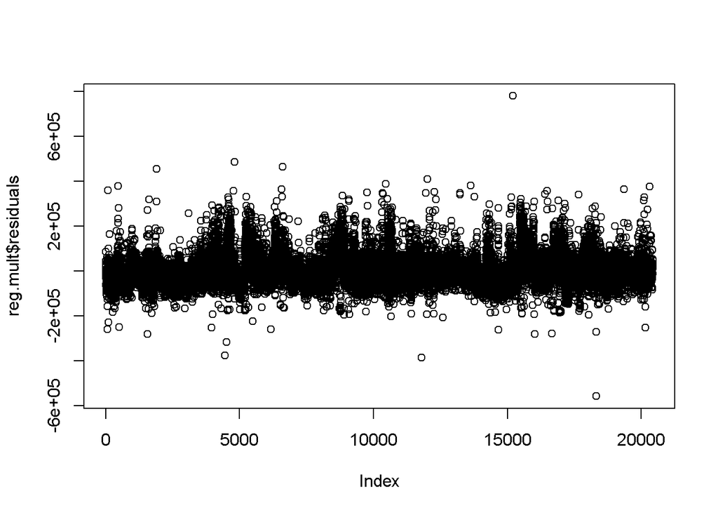

```r
plot(reg.mult$residuals)
```

```r
lillie.test(reg.mult$residuals)
```

```
##
##  Lilliefors (Kolmogorov-Smirnov) normality test
##
## data:  reg.mult$residuals
## D = 0.090731, p-value < 2.2e-16
```

*Este modelo no cumple todos los supuestos, la media se puede considerar 0 y podemos también considerar homocedasticidad ya que en el plot no se observan tendencias, se ven puntos aleatorios, sin embargo, los residuos no son normales según el método analítico, además, este modelo se puede mejorar haciendo algunos ajustes.*

## Colinealidad

```r
vif(reg.mult)
```

```
##                         GVIF Df GVIF^(1/(2*Df))
## longitude          18.090772  1        4.253325
## latitude           19.969176  1        4.468688
## housing_median_age  1.323622  1        1.150488
## total_rooms        12.966422  1        3.600892
## total_bedrooms     36.309883  1        6.025768
## population          6.446223  1        2.538941
## households         35.173375  1        5.930715
## median_income       1.786367  1        1.336550
## ocean_proximity     4.101702  4        1.192945
```

Se observan variables con un vif mayor que 10 lo cuál nos indica un problema de colinealidad entre varias variables, es decir, tenemos variables que están altamente correlacionadas y esto puede dar problemas en la estimación de los coeficientes por parte del modelo dando lugar a predicciones erróneas.

**Tendremos que eliminar algunas variables**

# Segundo modelo de regresión lineal múltiple

```r
reg.mult2 <- lm(log(median_house_value) ~ longitude + housing_median_age +                 log(total_rooms) + log(population) + median_income + ocean_proximity,
                data = housing)

summary(reg.mult2)
```

```
##
## Call:
## lm(formula = log(median_house_value) ~ longitude + housing_median_age +
##     log(total_rooms) + log(population) + median_income + ocean_proximity,
##     data = housing)
##
## Residuals:
##     Min      1Q  Median      3Q     Max
## -2.2535 -0.2132 -0.0180  0.1970  2.0275
##
## Coefficients:
##                             Estimate Std. Error t value Pr(>|t|)
## (Intercept)               10.5213479  0.1681270  62.580  < 2e-16 ***
## longitude                 -0.0052681  0.0013882  -3.795 0.000148 ***
## housing_median_age         0.0030216  0.0002124  14.226  < 2e-16 ***
## log(total_rooms)           0.2712931  0.0073025  37.151  < 2e-16 ***
## log(population)           -0.2284025  0.0072582 -31.468  < 2e-16 ***
## median_income              0.1447805  0.0014651  98.817  < 2e-16 ***
## ocean_proximityINLAND     -0.5581443  0.0061659 -90.521  < 2e-16 ***
## ocean_proximityISLAND      0.6543284  0.1527016   4.285 1.84e-05 ***
## ocean_proximityNEAR BAY   -0.0226239  0.0094414  -2.396 0.016572 *
## ocean_proximityNEAR OCEAN  0.0073577  0.0076086   0.967 0.333539
## ---
## Signif. codes:  0 '***' 0.001 '**' 0.01 '*' 0.05 '.' 0.1 ' ' 1
##
## Residual standard error: 0.3412 on 20630 degrees of freedom
## Multiple R-squared:  0.6408, Adjusted R-squared:  0.6406
## F-statistic:  4089 on 9 and 20630 DF,  p-value: < 2.2e-16
```

```r
vif(reg.mult2)
```

```
##                        GVIF Df GVIF^(1/(2*Df))
## longitude          1.371567  1        1.171139
## housing_median_age 1.266895  1        1.125564
## log(total_rooms)   5.339871  1        2.310816
## log(population)    5.094223  1        2.257039
## median_income      1.373653  1        1.172029
## ocean_proximity    1.734426  4        1.071259
```

```r
AIC(reg.mult2)
```

```
## [1] 14197.04
```

Hemos transformado las variables grandes en logaritmos para que esté todo más concentrado y no tener variables sesgadas.

Como vemos, el modelo mejora drásticamente en términos de AIC y en general los problemas de colinealidad se han corregido, ahora solo tenemos dos variables que presentan una correlación moderada (vif cercano a 5).

Los modelos presentan coeficientes de determinación similares, luego, de acuerdo con el criterio del AIC, para predicciones más precisas utilizaremos el segundo modelo, ya que este ofrece menos ‘ruido’.

**Nuestro modelo explica el 64,08% de los cambios en los precios.**

# Análisis de residuos

Condiciones que deben cumplirse para los residuos:

1. Media = 0
2. Homocedasticidad (varianza constante)
3. Normalidad

```r
mean(reg.mult2$residuals)
```

```
## [1] 2.487879e-17
```

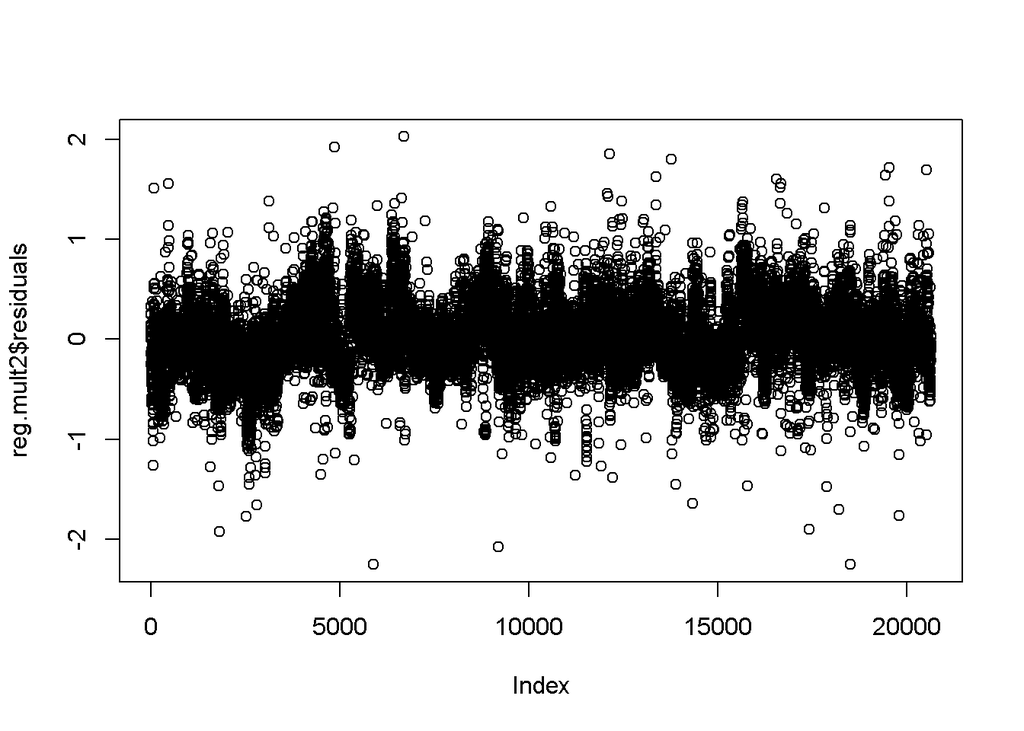

```r
plot(reg.mult2$residuals)
```

```r
lillie.test(reg.mult2$residuals)
```

```
##
##  Lilliefors (Kolmogorov-Smirnov) normality test
##
## data:  reg.mult2$residuals
## D = 0.033859, p-value < 2.2e-16
```

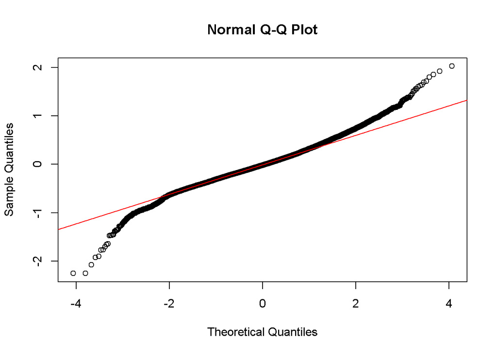

```r
qqnorm(reg.mult2$residuals)
qqline(reg.mult2$residuals, col ="red")
```

*Los residuos tienen problemas de normalidad por el método analítico, sin embargo, cuando los analizamos gráficamente vemos que en la media [-2, 2], los residuos se ajustan bastante bien a la recta y que los problemas están en las colas con algunos outliers. Al estar trabajando con inferencia bayesiana y al tratarse de un análisis de prueba, podemos dejar pasar este hecho. Si quisieramos un análisis más robusto podríamos usar una distribución t de student ya que esta admite más peso en sus colas.*

# Interpretación de las variables

**Con respecto a la proximidad del mar, el modelo toma como referencia las que están a menos de 1 hora del mar.**

Las variables que más influyen en el precio son el estar ubicado en **interiores** o en una **isla**

# Modelo utilizando una distribución t de student

Probaremos a utilizar esta distribución ya que admite más peso en sus colas y quizás soporte de mejor manera los outliers para llegar a predicciones más precisas.

```r
reg.mult.tstudent <- brm(
  formula = log(median_house_value) ~ longitude + housing_median_age +
            log(total_rooms) + log(population) + median_income + ocean_proximity,
  data = housing,
  family = student(),
  prior = c(
    prior(normal(0, 5), class = "b"),
    prior(normal(0, 5), class = "Intercept"),
    prior(student_t(3, 0, 10), class = "sigma"),
    prior(gamma(2, 0.1), class = "nu") # grados de libertad
  ),
  chains = 4,
  iter = 6000,
  cores = 4, # Ajustar según la CPU
  warmup = 1000,
  seed = 123
)
summary(reg.mult.tstudent)
```

```
##  Family: student
##   Links: mu = identity; sigma = identity; nu = identity
## Formula: log(median_house_value) ~ longitude + housing_median_age + log(total_rooms) + log(population) + median_income + ocean_proximity
##    Data: housing (Number of observations: 20640)
##   Draws: 4 chains, each with iter = 6000; warmup = 1000; thin = 1;
##          total post-warmup draws = 20000
##
## Regression Coefficients:
##                          Estimate Est.Error l-95% CI u-95% CI Rhat Bulk_ESS
## Intercept                    9.75      0.16     9.43    10.07 1.00    22041
## longitude                   -0.01      0.00    -0.01    -0.01 1.00    21575
## housing_median_age           0.00      0.00     0.00     0.00 1.00    21312
## logtotal_rooms               0.30      0.01     0.29     0.32 1.00    10678
## logpopulation               -0.25      0.01    -0.27    -0.24 1.00    10614
## median_income                0.15      0.00     0.14     0.15 1.00    16457
## ocean_proximityINLAND       -0.57      0.01    -0.58    -0.56 1.00    14303
## ocean_proximityISLAND        0.67      0.14     0.39     0.94 1.00    15145
## ocean_proximityNEARBAY      -0.05      0.01    -0.07    -0.03 1.00    15273
## ocean_proximityNEAROCEAN     0.02      0.01     0.01     0.04 1.00    16852
##                          Tail_ESS
## Intercept                   16640
## longitude                   16532
## housing_median_age          16717
## logtotal_rooms              12821
## logpopulation               12117
## median_income               15394
## ocean_proximityINLAND       13482
## ocean_proximityISLAND       12387
## ocean_proximityNEARBAY      14021
## ocean_proximityNEAROCEAN    14364
##
## Further Distributional Parameters:
##       Estimate Est.Error l-95% CI u-95% CI Rhat Bulk_ESS Tail_ESS
## sigma     0.29      0.00     0.28     0.29 1.00    11321    13787
## nu        6.95      0.33     6.34     7.62 1.00    10923    13626
##
## Draws were sampled using sampling(NUTS). For each parameter, Bulk_ESS
## and Tail_ESS are effective sample size measures, and Rhat is the potential
## scale reduction factor on split chains (at convergence, Rhat = 1).
```

*Debemos tener en cuenta que, en este caso, estamos utilizando muestreo MCMC, por lo que los coeficientes estimados pueden variar ligeramente según la semilla utilizada, ya que el procedimiento se basa en cadenas de muestreo aleatorias.*

## Diagnóstico gráfico

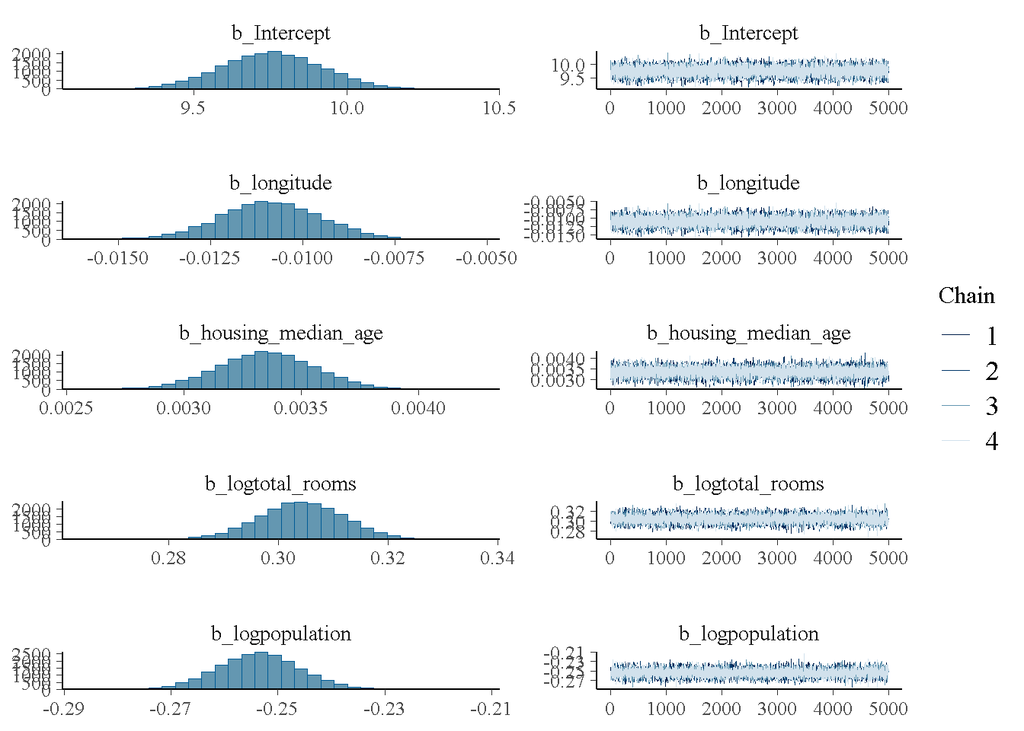

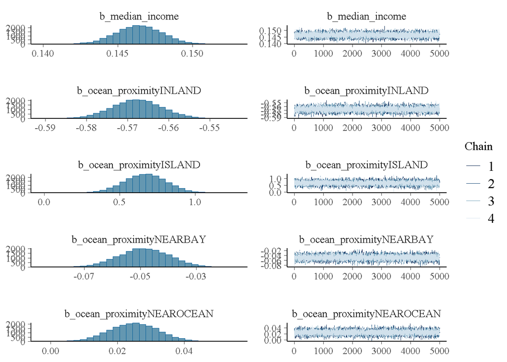

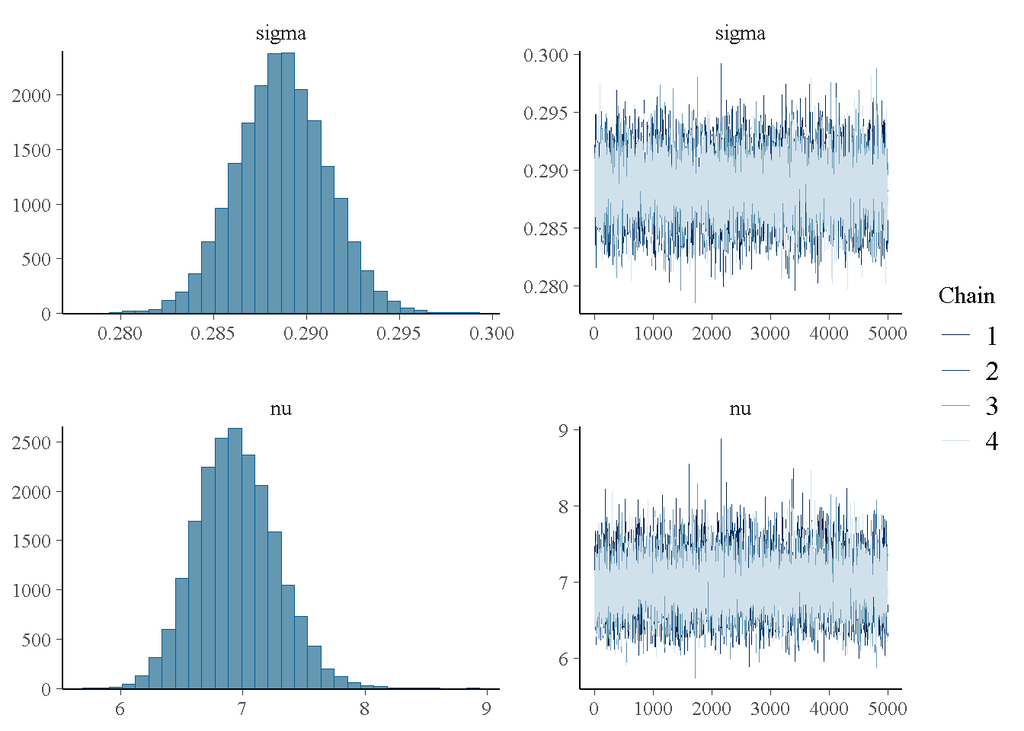

```r
plot(reg.mult.tstudent)      # Cadenas MCMC
```

Como vemos, las cadenas se mezclan de manera decente, lo que quiere decir que, en principio, estamos llegando a una predicción representativa y fiable de las distribuciones a posteriori de los parámetros.

```r
pp_check(reg.mult.tstudent)  # Ver si los datos simulados se ajustan bien
```

```
## Using 10 posterior draws for ppc type 'dens_overlay' by default.
```

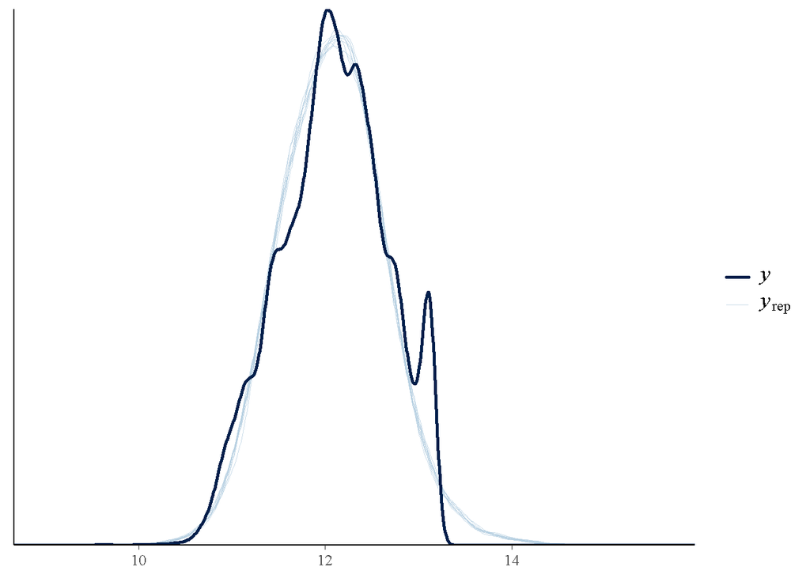

Sin embargo, cuando se simulan datos basados en esas distribuciones a posteriori y se comparan con los datos reales, vemos que el modelo no está captando bien los datos de la distribución observada como, por ejemplo, ese segundo pico.

## Coeficiente de determinación

```r
bayes_R2(reg.mult.tstudent)
```

```
##     Estimate   Est.Error      Q2.5     Q97.5
## R2 0.6511544 0.002137614 0.6468699 0.6552633
```

En cuanto al coeficiente de determinación vemos que este es ligeramente superior al del modelo gaussiano.

# Conclusiones

*Tras comparar ambos modelos podemos ver que a pesar de usar una t de student los outliers siguen siendo un problema como podemos ver en el diagnóstico gráfico, sin embargo, las cadenas para los parámetros del modelo convergen bien. Podemos afirmar que no sería mala idea utilizar este modelo ya que los grados de libertad de la distribución son aproximadamente 7 y no es un número muy grande por lo que se aleja de una normal y quizás soporta de mejor manera los outliers que presentan los datos a pesar de que no lo hace de manera perfecta.*

*Esto puede deberse a una relación no lineal entre las distintas variables, multimodalidad en los datos o el hecho de que pueden haber variables omitidas que son relevantes y que no están en el modelo*

**A pesar de eso, creo que ambos modelos ofrecen una alternativa razonable para estimar la relación entre el precio de las casas y las variables explicativas.**